# Data Analysis Homework Danilova Elizaveta 164

## Spline regression

Though according to the previous analysis, the non-linear effect in the model is not necessary, the task consider using one, so I decided to prove the non-linear effect of the “finance” variable, that should not be linear to see the happiness paradox. I choose spline regression, because it can help to identify the exact variation in distribution, using the high number of knots. The summary of the spline regression shows the significant effect on some divided knots, most of them are at the last knots, that shows that the high financial situation is associated with the high level of happiness. The graph, however, shows that there are sharp decrease in happiness index at the 7 and 8 values of finance variable, which can be explained by the lack of the data or that the respondents prefer to choose either average or high number in describing finance level. In that case people with the high financial level are less happy than with the average level, which can be a sign of Australian paradox. The non-linear effect on health shows also significant result. The line graph and model results are similar with the previous boxplot distribution, where the poor health is significantly correlated with the low happiness level, the effect on this variable is still very close to the linear one.

```r
# Build the model
data_1 <- na.exclude(data_as)
knots1 <- quantile(data_1$health, p = c(0.25, 0.5, 0.75))
model_hel <- lm (happy_coded ~ bs(health, knots = knots1), data = data_1)
summary(model_hel)
```

```
##
## Call:
## lm(formula = happy_coded ~ bs(health, knots = knots1), data = data_1)
##
## Residuals:
##      Min       1Q   Median       3Q      Max
## -1.96958 -0.26829  0.03042  0.40047  1.20000
##
## Coefficients: (3 not defined because of singularities)
##                             Estimate Std. Error t value Pr(>|t|)
## (Intercept)                  2.80000    0.08051  34.780  < 2e-16 ***
## bs(health, knots = knots1)1 -1.10876    0.12532  -8.847  < 2e-16 ***
## bs(health, knots = knots1)2  1.40488    0.24966   5.627 2.22e-08 ***
## bs(health, knots = knots1)3       NA         NA      NA       NA
## bs(health, knots = knots1)4       NA         NA      NA       NA
## bs(health, knots = knots1)5  0.79953    0.08469   9.441  < 2e-16 ***
## bs(health, knots = knots1)6       NA         NA      NA       NA
## ---
## Signif. codes:  0 '***' 0.001 '**' 0.01 '*' 0.05 '.' 0.1 ' ' 1
##
## Residual standard error: 0.54 on 1382 degrees of freedom
## Multiple R-squared:  0.163,  Adjusted R-squared:  0.1611
## F-statistic: 89.69 on 3 and 1382 DF,  p-value: < 2.2e-16
```

```r
model_hel1 <- lm (happy_coded ~ bs(health, knots = knots1) + finance + family + child + free + national, data = data_1)
summary(model_hel1)
```

```
##
## Call:
## lm(formula = happy_coded ~ bs(health, knots = knots1) + finance +
##     family + child + free + national, data = data_1)
##
## Residuals:
##      Min       1Q   Median       3Q      Max
## -1.72946 -0.35767 -0.05172  0.39693  1.29191
##
## Coefficients: (3 not defined because of singularities)
##                              Estimate Std. Error t value Pr(>|t|)
## (Intercept)                  0.967416   0.195122   4.958 8.01e-07 ***
## bs(health, knots = knots1)1 -0.734093   0.118410  -6.200 7.47e-10 ***
## bs(health, knots = knots1)2  0.656548   0.237007   2.770  0.00568 **
## bs(health, knots = knots1)3        NA         NA      NA       NA
## bs(health, knots = knots1)4        NA         NA      NA       NA
## bs(health, knots = knots1)5  0.462754   0.082088   5.637 2.09e-08 ***
## bs(health, knots = knots1)6        NA         NA      NA       NA
## finance                      0.030529   0.006198   4.925 9.44e-07 ***
## family                       0.194926   0.042200   4.619 4.21e-06 ***
## child                        0.010600   0.009196   1.153  0.24924
## free                         0.081891   0.008135  10.066  < 2e-16 ***
## national                     0.098469   0.023582   4.176 3.16e-05 ***
## ---
## Signif. codes:  0 '***' 0.001 '**' 0.01 '*' 0.05 '.' 0.1 ' ' 1
##
## Residual standard error: 0.4967 on 1377 degrees of freedom
## Multiple R-squared:  0.2946, Adjusted R-squared:  0.2905
## F-statistic: 71.87 on 8 and 1377 DF,  p-value: < 2.2e-16
```

```r
knots <- quantile(data_1$finance, p = c(0.25, 0.5, 0.75))
model_fin <- lm (happy_coded ~ bs(finance, knots = knots), data = data_1)
summary(model_fin)
```

```
##
## Call:
## lm(formula = happy_coded ~ bs(finance, knots = knots), data = data_1)
##
## Residuals:
##     Min      1Q  Median      3Q     Max
## -2.2440 -0.3502 -0.1405  0.4967  0.9739
##
## Coefficients:
##                             Estimate Std. Error t value Pr(>|t|)
## (Intercept)                  3.06326    0.08801  34.806  < 2e-16 ***
## bs(finance, knots = knots)1 -0.07411    0.17770  -0.417 0.676706
## bs(finance, knots = knots)2 -0.03871    0.13155  -0.294 0.768612
## bs(finance, knots = knots)3  0.27589    0.11622   2.374 0.017739 *
## bs(finance, knots = knots)4  0.24601    0.11604   2.120 0.034181 *
## bs(finance, knots = knots)5  0.54228    0.14290   3.795 0.000154 ***
## bs(finance, knots = knots)6  0.57234    0.09859   5.806 7.95e-09 ***
## ---
## Signif. codes:  0 '***' 0.001 '**' 0.01 '*' 0.05 '.' 0.1 ' ' 1
##
## Residual standard error: 0.5609 on 1379 degrees of freedom
## Multiple R-squared:  0.0989, Adjusted R-squared:  0.09498
## F-statistic: 25.22 on 6 and 1379 DF,  p-value: < 2.2e-16
```

```r
model_fin1 <- lm (happy_coded ~ bs(finance, knots = knots) + health + family + child + free + national, data = data_1)
summary(model_fin1)
```

```
##
## Call:
## lm(formula = happy_coded ~ bs(finance, knots = knots) + health +
##     family + child + free + national, data = data_1)
##
## Residuals:
##      Min       1Q   Median       3Q      Max
## -1.81132 -0.34858 -0.05157  0.40125  1.22508
##
## Coefficients:
##                              Estimate Std. Error t value Pr(>|t|)
## (Intercept)                  0.785333   0.201260   3.902 1.00e-04 ***
## bs(finance, knots = knots)1 -0.139721   0.157811  -0.885    0.376
## bs(finance, knots = knots)2 -0.111353   0.116658  -0.955    0.340
## bs(finance, knots = knots)3  0.049750   0.104027   0.478    0.633
## bs(finance, knots = knots)4 -0.029346   0.104151  -0.282    0.778
## bs(finance, knots = knots)5  0.188887   0.128423   1.471    0.142
## bs(finance, knots = knots)6  0.196272   0.090354   2.172    0.030 *
## health                       0.207935   0.018274  11.379  < 2e-16 ***
## family                       0.192530   0.042190   4.563 5.48e-06 ***
## child                        0.009756   0.009213   1.059    0.290
## free                         0.078855   0.008099   9.736  < 2e-16 ***
## national                     0.100595   0.023577   4.267 2.12e-05 ***
## ---
## Signif. codes:  0 '***' 0.001 '**' 0.01 '*' 0.05 '.' 0.1 ' ' 1
##
## Residual standard error: 0.4967 on 1374 degrees of freedom
## Multiple R-squared:  0.2959, Adjusted R-squared:  0.2903
## F-statistic: 52.51 on 11 and 1374 DF,  p-value: < 2.2e-16
```

## Health plot

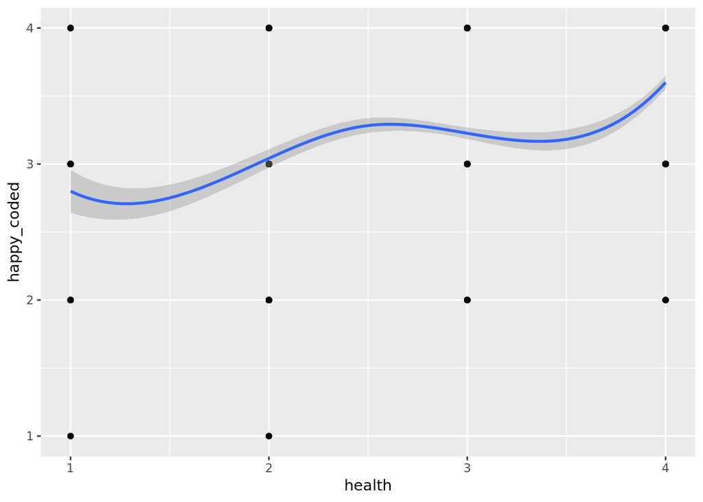

```r
ggplot(data_1, aes(health,happy_coded) ) +
  geom_point() +
  stat_smooth(method = lm, formula = y ~ splines::bs(x, df = 4))
```

## Finance plot

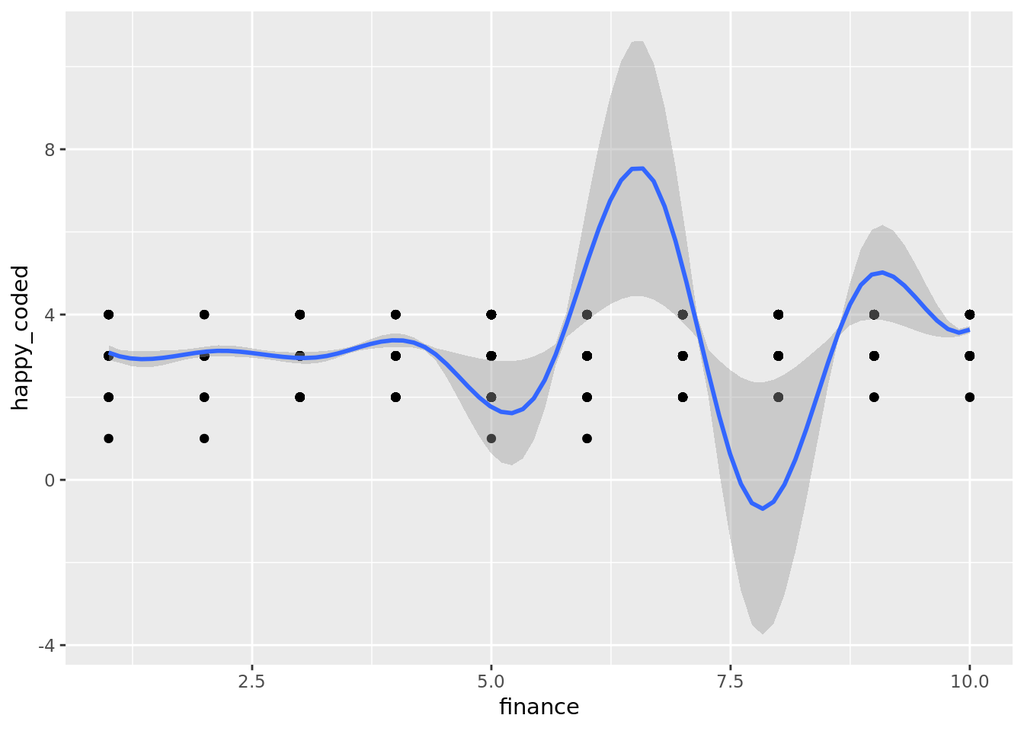

```r
ggplot(data_1, aes(finance,happy_coded) ) +
  geom_point() +
  stat_smooth(method = lm, formula = y ~ splines::bs(x, df = 10))
```